# All my homework

Yiming Ma

2020-12-15

# 9.22

## Example 1

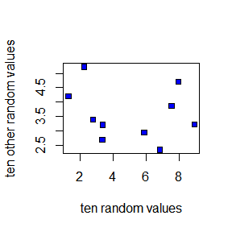

```r
x<-runif(10,1,10)
y<-runif(10,2,6)
plot(x,y,xlab = "ten random values",ylab = "ten other random values",bg="blue",pch=22)
```

## Example 2

```r
tab <- readxl::read_excel("C:/rlearn/生产总值.xls",sheet=1)
```

```
## * `` -> ...1
```

```r
knitr::kable(tab)
```

| …1 | 指标名称 | 地区名称 | 指标单位 | 2019年09月 | 2019年12月 | 2020年03月 | 2020年06月 |
| --- | --- | --- | --- | --- | --- | --- | --- |
| 国内生产总值及产业结构(季度) | 国内生产总值(累计) | 全国 | 亿元 | 712845.4 | 990865.1 | 206504.3 | 456614.4 |
| NA | 国内生产总值(累计)同比增长率 | NA | % | 6.2 | 6.1 | -6.8 | -1.6 |
| NA | 第一产业增加值(累计) | NA | 亿元 | 43005.0 | 70466.7 | 10186.2 | 26053.0 |
| NA | 第一产业增加值(累计)同比增长率 | NA | % | 2.9 | 3.1 | -3.2 | 0.9 |
| NA | 第二产业增加值(累计) | NA | 亿元 | 276912.5 | 386165.3 | 73638.0 | 172759.0 |
| NA | 第二产业增加值(累计)同比增长率 | NA | % | 5.6 | 5.7 | -9.6 | -1.9 |
| NA | 第三产业增加值(累计) | NA | 亿元 | 392927.9 | 534233.1 | 122680.1 | 257802.4 |
| NA | 第三产业增加值(累计)同比增长率 | NA | % | 7.0 | 6.9 | -5.2 | -1.6 |

这是季度生产总值和产业结构的表格，数据来自中宏数据库

## Example 3

如果我们定义风险的市场价格为
$$\Theta(t)=\frac{\alpha(t)-R(t)}{\sigma(t)}$$
在Girsanov Thearem中取$L_{t} =-\int_{0}^{t} \Theta(u) d W(u)$ ，因为
$$\langle \Theta \cdot W,\Theta \cdot W \rangle =\Theta^{2}\cdot\langle W,W\rangle$$
那么得到
$$Z_{t}=\mathscr{E}(L) =\exp \left(L_{t}-\frac{1}{2}\langle L, L\rangle_{t}\right)
=\exp \left\{-\int_{0}^{t} \Theta(u) d W(u)-\frac{1}{2} \int_{0}^{t} \Theta^{2}(u) d u\right\}$$

# 9.29

## Exercise 3.3

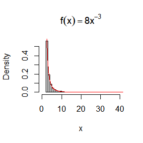

```r
n<-5000
u<-runif(n)
x<-2/(sqrt(1-u))
hist(x,breaks=100,prob=TRUE,xlim=c(0,40),main = expression(f(x)==8*x^-3))
y<-seq(0,100,.1)
lines(y,8*y^-3,col="red")
```

通过比较频率直方图和密度图发现基本吻合

## Exercise 3.8 3.9

```r
f<-function(){
u1<-runif(1,min = -1,max = 1)
u2<-runif(1,min = -1,max = 1)
u3<-runif(1,min = -1,max = 1)
x<-1
  if(abs(u3)>=abs(u2)&&abs(u3)>=abs(u1))
    {x=u2}else
    x=u3
}
```

以上定义了一个生成符合分布抽样函数，下面通过该函数生产大模拟样本直方图

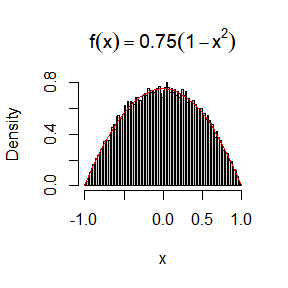

```r
x<-1:50000
for (i in 1:50000) {
  x[i]=f()
  i=i+1
}
hist(x,prob=TRUE,breaks = 90,main = expression(f(x)==0.75*(1-x^2)))
y<-seq(-1,1,0.1)
lines(y,0.75*(1-y^2),col="red")
```

发现密度曲线和大模拟样本直方图比较接近，可以认为该算法符合密度函数。

## Exercise 3.9

证明： 我们假定输出结果为一个新的随机变量$U$，现在即要证明$\textit{P}(U=x)=\frac{3}{4}\left(1-x^{2}\right)$,将该算法各种情况分开考虑
$$\begin{align}\textit{P}(U=x)&=\textit{P}(U_2=x,|U_3|\ge|U_2|,|U_3|\ge|U_1|)+\textit{P}(U_3=x,|U_3| < |U_2|,|U_3|\ge|U_1|)\\
&+\textit{P}(U_3=x,|U_3|\ge|U_2|,|U_3|<|U_1|)+\textit{P}(U_3=x,|U_3|<|U_2|,|U_3|<|U_1|)\\&=0.25(1-x^2)+0.25(1-x)^2+0.25(1-x)^2+|x|(1-|x|)\\&=0.75(1-x^2)
\end{align}$$

#10.13

## 5.1

考虑是$g(x)=\frac{\pi}{3}sinx$对于$[0,\frac{\pi}{3}]$上的均匀分布的期望

```r
set.seed(12345)
m<- 1e5
x<- runif(m,min=0,max= pi/3)
M<- mean(sin(x))*pi/3
print(c(M,1-cos(pi/3)))
```

```
## [1] 0.500536 0.500000
```

这说明蒙特卡洛估计和积分的精确值很接近。

## 5.6

可以计算得到如下结果
$$\begin{align}
Cov(e^{U},e^{1-U})&=E(e^U*e^{1-U})-E(e^U)*E(e^{1-U})\\
&=E(e)-(E(e^U))^2\\
&=e-(e-1)^2\\
&=3e-e^2-1
\end{align}$$
$$\begin{align}
Var(e^U+e^{1-U})&=E[(e^U+e^{1-U})^2]-(E(e^U+e^{1-U}))^2\\
&=E(e^{2U}+2e^U*e^{1-U}+e^{2(1-U)})-(2*E(e^U))^2\\
&=e^2-1+2e-(2(e-1))^2\\
&=10e-3e^2-5
\end{align}$$
$$\begin{align}
Var(e^U)&=E(e^{2u})-(E(e^U))^2\\
&=2e-0.5e^2-1.5
\end{align}$$
则可以计算出理论上可以减少的方差比率为$1-\frac{\frac{1}{4}Var(e^U+e^{1-U})}{Var(e^U)}=0.9838$

## 5.7

```r
set.seed(2333)
m1<- 2000000
m2<- 2000000
X<- runif(m1,min = 0,max = 1)
Y<- runif(m2,min = 0,max = 1)
X_1<-exp(X)
Y_1<-0.5*exp(Y)+0.5*exp(1-Y)
M1<- mean(exp(X))
M2<- mean(0.5*exp(Y)+0.5*exp(1-Y))
V1<- var(X_1)
V2<- var(Y_1)
cat("这是简单蒙特卡洛方法的结果和方差:",M1,V1)
```

```
## 这是简单蒙特卡洛方法的结果和方差: 1.718148 0.2420739
```

```r
cat("这是采用对偶变量的方法的结果和方差:",M2,V2)
```

```
## 这是采用对偶变量的方法的结果和方差: 1.718252 0.003913245
```

可以计算出模拟得到的消除方差比率为0.9838。这和理论值非常吻合

## 5.11

假设$\hat{\theta_1}$和$\hat{\theta_2}$是$\theta$的两个无偏估计，那么易知$\hat{\theta_c}=\hat{\theta_1}+(1-c)\hat{\theta_2}$也是一个无偏估计量。那么他的方差可以计算得到
$$\begin{align}
Var(\hat{\theta_c})&=Var(\hat{\theta_2})+c^2Var(\hat{\theta_1}-\hat{\theta_2})+2cCov(\hat{\theta_2},\hat{\theta_1}-\hat{\theta_2})
\end{align}$$
这是一个关于$c$的二次函数，开口向上，所以选取$c$取值为对称轴时取值最小。即
$$c^*=-\frac{Cov(\hat{\theta_2},\hat{\theta_1}-\hat{\theta_2})}{Var(\hat{\theta_1}-\hat{\theta_2})}$$

# 10.20

## 5.13

首先先画出$g(x)$的图象

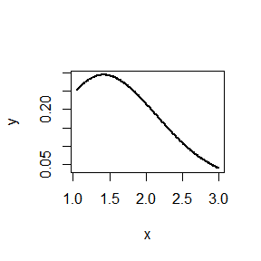

```r
x<- seq(1.05,3,.01)
g<- function(x){
  ((x^2)*exp(-0.5*x^2))/((2*pi)^0.5)*(x>1)
}
y<- g(x)
plot(x,y,lwd=2,type = "l")
```

推测正态分布和参数是3的卡方分布是比较好的重要函数

```r
set.seed(123)
zt<- rnorm(500000,0,1)
kf<- rchisq(500000,3)
fg_1<- g(zt)/dnorm(zt)
fg_2<- g(kf)/dchisq(kf,3)
g1<- mean(fg_1)
se1<- sd(fg_1)
g2<- mean(fg_2)
se2<- sd(fg_2)
cat("重要函数取正态分布的结果和标准差:" ,g1 ,se1)
```

```
## 重要函数取正态分布的结果和标准差: 0.4021338 1.136242
```

```r
cat("重要函数取卡方分布的结果和标准差:" ,g2 ,se2)
```

```
## 重要函数取卡方分布的结果和标准差: 0.4010007 0.4955383
```

```r
print(integrate(g,1,Inf)) #这是标准的结果
```

```
## 0.400626 with absolute error < 5.7e-07
```

综上，发现用卡方分布做重要函数是比较好的，结果准确且方差小。

## 5,15

考虑密度函数为$f(x)=\frac{5e^{-x}}{1-e^{-1}}$,那么考虑五个等概率的区间，分别对五个区间进行重要抽样相加就是估计值，方差是各部分的方差相加

```r
g1<- function(x){
  (exp(-x)/(1+x^2))*(x>0)*(x<1)
}
result<- matrix(0,5,2)
m<- 2500
for (i in 1:5) {
  rn<- runif(m,0,1)
  q<- -log(1-((1-exp(-1))*(rn + i -1)/5))
  fg<- g1(q)/((5*(exp(-q)))/(1-exp(-1)))
  result[i,1]<- mean(fg)
  result[i,2]<- var(fg)
}
cat("分层重要抽样的结果是:",sum(result[,1]))
```

```
## 分层重要抽样的结果是: 0.5243908
```

```r
cat("分层重要抽样的方差是:",sum(result[,2]))
```

```
## 分层重要抽样的方差是: 8.787938e-05
```

```r
print(integrate(g1,0,1)) #求一个积分的标准值
```

```
## 0.5247971 with absolute error < 5.8e-15
```

通过比较发现，分层重要抽样无论是结果还是方差都要更优。

## 6.4

先从参数为0；1的对数正态分布中抽样，再计算$\mu$理论上95%的置信区间,再计算这些区间包含 0的频率，和95%进行比较。

```r
w<- 0
n<- 20
alpha<- 0.05
t<-0
s<- matrix(0,10000,2)
for (i in 1:10000) {
  x<- rlnorm(n,0,1)
  s[i,1]<- mean(log(x))+sd(log(x))*qt(alpha/2,n-1)/sqrt(n-1)
  s[i,2]<- mean(log(x))-sd(log(x))*qt(alpha/2,n-1)/sqrt(n-1)
  if(s[i,2]>0 & s[i,1]< 0) t<-t+1
}
t/10000
```

```
## [1] 0.9588
```

发现构造的置信区间的置信系数比较吻合理论。

## 6.5

```r
w1<- 0
n1<- 20
alpha<- 0.05
t<-0
s<- matrix(0,10000,2)
for (i in 1:10000) {
  x<- rchisq(n1,2)
  s[i,1]<- mean(x)+sd(x)*qt(alpha/2,n-1)/sqrt(n-1)
  s[i,2]<- mean(x)-sd(x)*qt(alpha/2,n-1)/sqrt(n-1)
  if(s[i,2]>2 & s[i,1]< 2) t<-t+1
}
t/10000
```

```
## [1] 0.9225
```

发现相比样本来自正态分布的置信系数低一些，但是相比书上方差区间的0.773，没有方差那么敏感，更稳定一些。

# 10.27

## 6.7

首先我么定义求样本偏度的函数

```r
sk<- function(x){
  xbar<- mean(x)
  m3<- mean((x-xbar)^3)
  m2<- mean((x-xbar)^2)
  return(m3/m2^1.5)
}
```

下面循环MC模拟求不同参数下的分布的$\alpha1=\alpha2=\alpha$的beta分布的犯第一类错误，置信水平此时固定为0.05

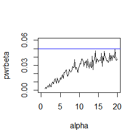

```r
a<- 0.05
n<- 30
m<- 2000
alpha<- c(seq(1,20,0.2))
N<- length(alpha)
sd<- sqrt(6*(n-2)/((n+1)*(n+3)))
cv<- qnorm(1-a/2,0,sd)
pwrbeta<- numeric(N)#储存不同参数的功效值
for (i in 1:N) {
  al<- alpha[i]
  sktests<- numeric(m)
  for (j in 1:m) {
    x<- rbeta(n,al,al)
    sktests[j]<- as.integer(abs(sk(x)) >= cv)
  }
  pwrbeta[i]<- mean(sktests)
}
plot(alpha,pwrbeta,type = "l",xlim = c(0,20),ylim = c(0,0.06))
abline(h=0.05,col="blue")
```

现在对对称的t分布进行模拟

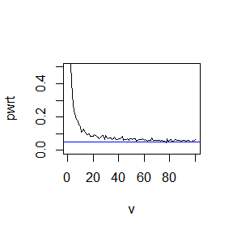

```r
v<- seq(1,100,1)
M<- length(v)
pwrt<- numeric(M)
for (i in 1:M) {
  vi<- v[i]
  sktests<- numeric(m)
  for (j in 1:m) {
    x<- rt(n,vi)
    sktests[j]<- as.integer(abs(sk(x)) >= cv)
  }
  pwrt[i]<- mean(sktests)
}
plot(v,pwrt,type = "l",ylim = c(0,0.5))
abline(h=0.05,col="blue")
```

可以发现对于beta分布，参数越大，检验反第一类错误的可能性是越大的,可以画出不同参数的beta图象，其中红色的是正态分布作为对比，这是因为参数越大，越接近一个正态分布。所以由正态分布推出的检验的会在在参数越大时越接近置信系数。

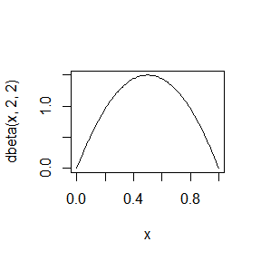

```r
curve(dbeta(x, 2, 2), from = 0, to = 1)
```

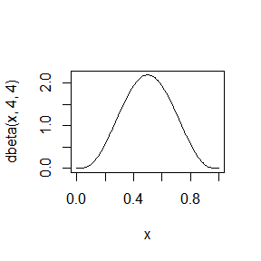

```r
curve(dbeta(x, 4, 4), from = 0, to = 1)
```

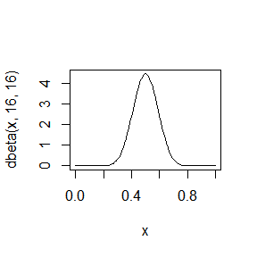

```r
curve(dbeta(x, 16, 16), from = 0, to = 1)
```

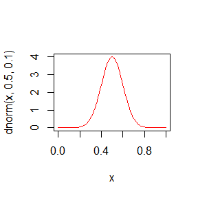

```r
curve(dnorm(x,0.5,0.1),from =0,to =1,col="red")
```

同样的画出不同参数t分布的密度函数图象,其中红色是正态分布作为对比

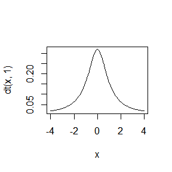

```r
curve(dt(x,1),from = -4,to =4)
```

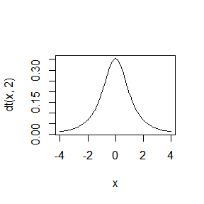

```r
curve(dt(x,2),from = -4,to =4)
```

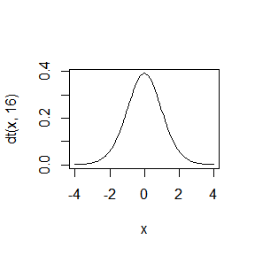

```r
curve(dt(x,16),from = -4,to =4)
```

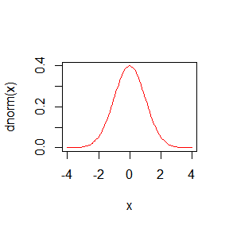

```r
curve(dnorm(x),from = -4,to =4,col="red")
```

同样的，发现t分布在参数越大时越接近正态分布，所以同样的功效会接近置信系数。

## 6.8

先定义count5检验的函数，输出值1代表认为拒绝等方差，0则相反。

```r
count5test<- function(x,y){
  X<- x-mean(x)
  Y<- y-mean(y)
  outx<- sum(X>max(Y))+sum(X<min(Y))
  outy<- sum(Y>max(X))+sum(Y<min(X))
  return(as.integer(max(c(outy,outx))>5))
}
```

由数理统计知识，我们指导F检验对于两个正态分布进行等方差检验是一个很好的方法，下面定义F检验函数

```r
Ftest<- function(x,y){
  xl<- length(x)
  yl<- length(y)
  sx<- var(x)
  sy<- var(y)
  T<- sy/sx
  return(as.integer(T<qf(0.055/2,xl-1,yl-2)|T>qf(1-0.055/2,xl-1,yl-1)))
}
```

那么接下来对不同大小样本分布进行count5和F检验。

### 小样本

```r
n1<-10
rnum<-2000
sig1<- 1
sig2<- 1.5
minpowercount5<-mean(
  replicate(rnum,expr = {
    x<- rnorm(n1,0,sig1)
    y<- rnorm(n1,0,sig2)
    count5test(x,y)
  })
)
minpowerF<-mean(replicate(rnum,expr = {
  x<- rnorm(n1,0,sig1)
  y<- rnorm(n1,0,sig1)
  Ftest(x,y)
})
)
cat("这是小样本count5检验的功效",minpowercount5)
```

```
## 这是小样本count5检验的功效 0.102
```

```r
cat("这是小样本F检验的功效",minpowerF)
```

```
## 这是小样本F检验的功效 0.046
```

### 中样本

```r
n2<-30
rnum<-2000
sig1<- 1
sig2<- 1.5
midpowercount5<-mean(
  replicate(rnum,expr = {
    x<- rnorm(n2,0,sig1)
    y<- rnorm(n2,0,sig2)
    count5test(x,y)
  })
)
midpowerF<-mean(replicate(rnum,expr = {
  x<- rnorm(n2,0,sig1)
  y<- rnorm(n2,0,sig2)
  Ftest(x,y)
})
)
cat("这是中样本count5检验的功效",midpowercount5)
```

```
## 这是中样本count5检验的功效 0.472
```

```r
cat("这是中样本F检验的功效",midpowerF)
```

```
## 这是中样本F检验的功效 0.5835
```

### 大样本

```r
n3<-100
rnum<-200
sig1<- 1
sig2<- 1.5
maxpowercount5<-mean(
  replicate(rnum,expr = {
    x<- rnorm(n3,0,sig1)
    y<- rnorm(n3,0,sig2)
    count5test(x,y)
  })
)
maxpowerF<-mean(replicate(rnum,expr = {
  x<- rnorm(n3,0,sig1)
  y<- rnorm(n3,0,sig2)
  Ftest(x,y)
})
)
cat("这是中样本count5检验的功效",maxpowercount5)
```

```
## 这是中样本count5检验的功效 0.84
```

```r
cat("这是中样本F检验的功效",maxpowerF)
```

```
## 这是中样本F检验的功效 0.975
```

这说明F检验的功效函数样本数量越大功效增长越快。

## 6.C

```r
n=c(10,20,30,50,100)
cv<- matrix(0,5,2)
cv[,2]<- (6/n)*qchisq(0.975,4)
cv[,1]<- (6/n)*qchisq(0.025,4)
cv<-data.frame(cv,row.names = c(10,20,30,50,100))
colnames(cv)<- c("l","r")
cv
```

```
##              l         r
## 10  0.29065113 6.6859721
## 20  0.14532557 3.3429860
## 30  0.09688371 2.2286574
## 50  0.05813023 1.3371944
## 100 0.02906511 0.6685972
```

下面定义计算多维样本偏度统计量的计算函数

```r
library(MASS)
msk<- function(x){#x是一个n*d的矩阵，代表n个d维样本
  n=nrow(x)
  mlsig<- cov(x)*(n-1)/n
  cmlsig<- solve(mlsig)
  xbar<- colMeans(x)
  n2bd<- 0
  for (i in 1:n) {
    for (j in 1:n) {
      n2bd<-n2bd+(t(x[i,]-xbar)%*%cmlsig%*%(x[j,]-xbar))^3
    }
  }
  return(n2bd/(n^2))
}
```

```r
n<-c(10,20,30,50,100)
pM<- 1:5
Sigma <- matrix(c(1,0,0,1),2,2)
for (i in 1:5) {
  msktests<- 1:1000
  for (j in 1:1000) {
    x<- mvrnorm(n[i], rep(0, 2), Sigma)
    v<- msk(x)
    if(v<cv[i,1]|v>cv[i,2])
      msktests[j]<-1 else
        msktests[j]<-0
  }
  pM[i]<- mean(msktests)
}
cat("这是对应的模拟置信系数",pM)
```

```
## 这是对应的模拟置信系数 0.071 0.059 0.053 0.057 0.045
```

下面对污染的多元正态分布的参数，计算多元偏度卡方检验的功效。

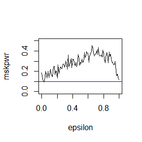

```r
n<-30
m<-200
Sigma <- matrix(c(1,0,0,1),2,2)
epsilon<-seq(0,1,0.01)
el<- length(epsilon)
mskpwr<-1:el
cv<-c((6/n)*qchisq(0.05,4),(6/n)*qchisq(0.95,4))
for (i in 1:el) {
  e<-epsilon[i]
  mskt<- numeric(m)
  for (j in 1:m) {
    k<- sample(c(0,1),replace = TRUE,size = n,prob = c(e,1-e))
    z<-matrix(0,20,2)
    x<- mvrnorm(n, rep(0, 2), Sigma)
    y<- mvrnorm(n, rep(0,2), 4*Sigma)
    for (h in 1:20) {
      if(k[h]==0)
        z[h,]<-x[h,]else
          z[h,]<-y[h,]
    }
    v<- msk(z)
    if(v<cv[1]|v>cv[2])
      mskt[j]<-1 else
        mskt[j]<- 0
  }
  mskpwr[i]<- mean(mskt)
}
 plot(epsilon,mskpwr,type = "l",ylim = c(0,0.5))
 abline(h= 0.1,col="blue")
```

可以发现，在$\epsilon$等于0或者1时，是很接近预先设定的0.1置信系数，这是因为在0或1时，是一个标准正态。

## Disscusion

$$\frac{\sum_{i=1}^{n}X_i-np}{\sqrt{n}(1-p)p}\rightarrow N(0,1)$$
因为这是大样本，所以将样本方差代替总体方差，分别对两组数据进行中心化近似，化简可以得到
$$p1-p2 \~{} N(\sum(X_i-Y_i),\frac{S_x^2+S_y^2}{n})$$

```r
#所以进行检验，发现其0.95的置信区间为
S<- (0.651*(1-0.651)+(1-0.676)*0.676)/10000
cat(qnorm(0.025,0.025,S),qnorm(0.975,0.025,S))
```

```
## 0.02491254 0.02508746
```

发现0不在里面，在0.05的水平上可以拒绝功效相同的原假设。

1.H0就是两种检验功效相等

2.大样本利用中心极限定理进行正太化近似，然后进行两正态分布的均值检验

3.因为MC检验法实际上已经在此功效下的二项分布抽样，所以题目已知数据已经足够。

# 11.3

## 7.1

```r
library(boot)
library(bootstrap)
corhat<- cor(law$LSAT,law$GPA)
n<- nrow(law)
corjack<- 1:n
for (i in 1:n) {
  LAST<- law$LSAT[-i]
  GPA<- law$GPA[-i]
  corjack[i]<- cor(LAST,GPA)
}
corbias<- (n-1)*(mean(corjack)-corhat)
se<- sqrt((n-1)*mean((corjack-mean(corjack))^2))
cat("This is jacknife's bias and standard error:",corbias,se)
```

```
## This is jacknife's bias and standard error: -0.006473623 0.1425186
```

## 7.5

we can easily to obtain the MLE of $\lambda$
$$\begin{aligned}
&\because f(x_1,x_2,...,x_n)=\lambda^ne^{-\lambda\sum_{i=1}^nx_i}\\
&\therefore lnf=nln\lambda-\lambda\sum_{i=1}^n x_i\\
& \therefore \frac{\partial lnf}{\partial \lambda}= \frac{n}{\lambda}-\sum_{i=1}^nx_i\\
&\therefore \lambda_{MLE}=\frac{n}{\sum_{i=1}^nx_i}
\end{aligned}$$

```r
f <- function(x,i){
  t<- x[i]
  12/sum(t)
}
air<- as.vector(aircondit$hours)
obj<- boot(data = air,statistic = f,R= 2000)
obj
```

```
##
## ORDINARY NONPARAMETRIC BOOTSTRAP
##
##
## Call:
## boot(data = air, statistic = f, R = 2000)
##
##
## Bootstrap Statistics :
##       original     bias    std. error
## t1* 0.00925212 0.00128106  0.00420192
```

```r
print(boot.ci(obj,type = c("basic","norm","perc","bca")))
```

```
## BOOTSTRAP CONFIDENCE INTERVAL CALCULATIONS
## Based on 2000 bootstrap replicates
##
## CALL :
## boot.ci(boot.out = obj, type = c("basic", "norm", "perc", "bca"))
##
## Intervals :
## Level      Normal              Basic
## 95%   (-0.0003,  0.0162 )   (-0.0025,  0.0132 )
##
## Level     Percentile            BCa
## 95%   ( 0.0053,  0.0210 )   ( 0.0046,  0.0177 )
## Calculations and Intervals on Original Scale
```

we can see the normal intervals is quite different with others,because the data is not come from a norm distribution.the basic way is not very accurate because wo do not know the distribution of $\lambda$’s estimation.and the per and bca way is more accurate than the others,because they are the quantities of bootstrap results,and bca has bias modification and adjusted for acceleration.

## 7.8

```r
scorm<- as.matrix(scor)
M<-cov(scorm)
t<- eigen(M)$val
val<- t[order(t,decreasing = TRUE)]
thetahat<-val[1]/sum(val)
n<- nrow(scor)
thetajack<-1:n
for (i in 1:n) {
  newscor<- scorm[-i,]
  M<-cov(newscor)
  t<- eigen(M)$val
  val<- t[order(t,decreasing = TRUE)]
  thetajack[i]<- val[1]/sum(val)
}
bias<- (n-1)*(mean(thetajack)-thetahat)
se<- sqrt((n-1)*mean((thetajack-mean(thetajack))^2))
cat("this is bias and se:",bias,se)
```

```
## this is bias and se: 0.001069139 0.04955231
```

## 7.11

```r
library(DAAG)
magnetic<- ironslag[,2]
chemical<- ironslag[,1]
n<- length(magnetic)
e1 <- e2 <- e3 <- e4<- matrix(0,n,n)
for (i in 2:n) {
  for (j in 1:i-1){
    y<- magnetic[-c(i,j)]
    x<- chemical[-c(i,j)]

    J1<-lm(y ~ x)
    yhat1i<- J1$coef[1]+J1$coef[2] * chemical[i]
    yhat1j<- J1$coef[1]+J1$coef[2] * chemical[j]
    e1[i,j]<- ((magnetic[i]-yhat1i)^2+(magnetic[j]-yhat1j)^2)/2

    J2<- lm(y ~ x + I(x^2))
    yhat2i<- J2$coef[1]+J2$coef[2]*chemical[i]+J2$coef[3]*chemical[i]^2
    yhat2j<- J2$coef[1]+J2$coef[2]*chemical[j]+J2$coef[3]*chemical[j]^2
    e2[i,j]<- ((magnetic[i]-yhat2i)^2+(magnetic[j]-yhat2j)^2)/2

    J3<- lm(log(y) ~ x)
    logyhat3i<- J3$coef[1]+J3$coef[2]*chemical[i]
    logyhat3j<- J3$coef[1]+J3$coef[2]*chemical[j]
    yhat3i<-exp(logyhat3i)
    yhat3j<-exp(logyhat3j)
    e3[i,j]<- ((magnetic[i]-yhat3i)^2+(magnetic[j]-yhat3j)^2)/2

    J4<- lm(log(y) ~ log(x))
    logyhat4i<- J4$coef[1]+J4$coef[2]*log(chemical[i])
    logyhat4j<- J4$coef[1]+J4$coef[2]*log(chemical[j])
    yhat4i<- exp(logyhat4i)
    yhat4j<- exp(logyhat4j)
    e4[i,j]<- ((magnetic[i]-yhat4i)^2+(magnetic[j]-yhat4j)^2)/2
  }
}
cat("these are four modoel's estimate error:",sum(e1)/1378,sum(e2)/1378,sum(e3)/1378,
    sum(e4)/1378)
```

```
## these are four modoel's estimate error: 19.57227 17.87018 18.45491 20.46718
```

so the result is the same as “leave one out”, the second model is more suitable.

# 11.10

## 8.3

利用不放回抽样，然后置换抽样，抽取比较适合count5检验的样本大小。

```r
count5test<- function(x,y){
  X<- x-mean(x)
  Y<- y-mean(y)
  outx<- sum(X>max(Y))+sum(X<min(Y))
  outy<- sum(Y>max(X))+sum(Y<min(X))
  return(as.integer(max(c(outy,outx))>5))
}
x<- rnorm(40,0,1)
y<- rnorm(30,0,1)
count5<- function(x,y,B){
  I<- numeric(B)
  xl<-length(x)
  yl<-length(y)
  for (i in 1:B) {
    xi<- sample(1:xl,20,replace = F)
    yi<- sample(1:yl,20,replace = F)
    newx<- x[xi]
    newy<- y[yi]
    I[i]<- count5test(newx,newy)
  }
  return((1+sum(I))/(B+1))
}
count5(x,y,1000)
```

```
## [1] 0.01298701
```

## discussion

```r
library(Ball)
library(energy)
library(boot)
library(RANN)
m<- 100
k<- 3
p<- 2
mu<- 0.3
set.seed(233)
n1<-n2<- 50
R<- 999
n<- n1+n2
N<- c(n1,n2)
Tn <- function(z, ix, sizes,k) {
  n1 <- sizes[1]; n2 <- sizes[2]; n <- n1 + n2
  if(is.vector(z)) z <- data.frame(z,0);
  z <- z[ix, ];
  NN <- nn2(data=z, k=k+1) # what's the first column?
  block1 <- NN$nn.idx[1:n1,-1]
  block2 <- NN$nn.idx[(n1+1):n,-1]
  i1 <- sum(block1 < n1 + .5); i2 <- sum(block2 > n1+.5)
  (i1 + i2) / (k * n)
}
eqdist.nn <- function(z,sizes,k){
  boot.obj <- boot(data=z,statistic=Tn,R=R,
                   sim = "permutation", sizes = sizes,k=k)
  ts <- c(boot.obj$t0,boot.obj$t)
  p.value <- mean(ts>=ts[1])
  list(statistic=ts[1],p.value=p.value)
}
p1.values <- matrix(NA,m,3)
for(i in 1:m){
  x <- matrix(rnorm(n1*p,0,1.5),ncol=p);
  y <- cbind(rnorm(n2),rnorm(n2,mean=0.3));
  z <- rbind(x,y)
  p1.values[i,1] <- eqdist.nn(z,N,k)$p.value
  p1.values[i,2] <- eqdist.etest(z,sizes=N,R=R)$p.value
  p1.values[i,3] <- bd.test(x=x,y=y,num.permutations=999,seed=i*12345)$p.value
}
alpha <- 0.1;
pow1 <- colMeans(p1.values<alpha)
pow1#上课的示例
```

```
## [1] 0.45 0.76 0.96
```

```r
p2.values <- matrix(NA,m,3)
for(i in 1:m){
  x <- matrix(rnorm(n1*p,0,1.6),ncol=p);
  y <- matrix(rnorm(n2*p,0,1),ncol=p);
  z <- rbind(x,y)
  p2.values[i,1] <- eqdist.nn(z,N,k)$p.value
  p2.values[i,2] <- eqdist.etest(z,sizes=N,R=R)$p.value
  p2.values[i,3] <- bd.test(x=x,y=y,num.permutations=999,seed=i*12345)$p.value
}
alpha <- 0.1
pow2 <- colMeans(p2.values<alpha)
pow2#等均值不等方差
```

```
## [1] 0.58 0.77 0.96
```

```r
p3.values <- matrix(NA,m,3)
for(i in 1:m){
  x <- matrix(rnorm(n1*p,0.3,1.4),ncol=p);
  y <- matrix(rnorm(n2*p,0,1),ncol=p);
  z <- rbind(x,y)
  p3.values[i,1] <- eqdist.nn(z,N,k)$p.value
  p3.values[i,2] <- eqdist.etest(z,sizes=N,R=R)$p.value
  p3.values[i,3] <- bd.test(x=x,y=y,num.permutations=999,seed=i*12345)$p.value
}
alpha <- 0.1
pow3 <- colMeans(p3.values<alpha)
pow3#不等均值不等方差
```

```
## [1] 0.53 0.71 0.90
```

```r
p4.values <- matrix(NA,m,3)
for(i in 1:m){
  x <- matrix(rt(n1*p,1) ,ncol=p)
  yy<- 1:n2*p
  a<- matrix(0,2,n2*p)
  a[1,]<- rnorm(n2*p,mean = -.1,2)
  a[2,]<- rnorm(n2*p,mean = .1,2)
  index<- sample(c(1,2),p*n2,replace = T,prob = c(.5,.5))
  for (j in 1:100) {
    yy[j]<-a[index[j],j]
  }
  y<-matrix(yy,ncol = p)
  z <- rbind(x,y)
  p4.values[i,1] <- eqdist.nn(z,N,k)$p.value
  p4.values[i,2] <- eqdist.etest(z,sizes=N,R=R)$p.value
  p4.values[i,3] <- bd.test(x=x,y=y,num.permutations=999,seed=i*12345)$p.value
}
alpha <- 0.1
pow4 <- colMeans(p4.values<alpha)
pow4#自由度为1的t分布
```

```
## [1] 0.55 0.61 0.53
```

```r
p5.values <- matrix(NA,m,3)
for(i in 1:m){
  x <- matrix(rt(n1*p,1) ,ncol=p)
  yy<- 1:n2*p
  a<- matrix(0,2,n2*p)
  a[1,]<- rnorm(n2*p,mean = -0.01,2)
  a[2,]<- rnorm(n2*p,mean = 0.01,2)
  index<- sample(c(1,2),p*n2,replace = T,prob = c(.5,.5))
  for (j in 1:100) {
    yy[j]<-a[index[j],j]
  }
  y<-matrix(yy,ncol = p)
  z <- rbind(x,y)
  p5.values[i,1] <- eqdist.nn(z,N,k)$p.value
  p5.values[i,2] <- eqdist.etest(z,sizes=N,R=R)$p.value
  p5.values[i,3] <- bd.test(x=x,y=y,num.permutations=999,seed=i*12345)$p.value
}
alpha <- 0.1
pow5 <- colMeans(p5.values<alpha)
pow5 #自由度为1的t分布和双正态
```

```
## [1] 0.55 0.60 0.49
```

```r
p6.values <- matrix(NA,m,3)
for(i in 1:m){
  x <- matrix(rnorm(100*p,0,1.5),ncol=p);
  y <- cbind(rnorm(10),rnorm(10));
  z <- rbind(x,y)
  p6.values[i,1] <- eqdist.nn(z,N,k)$p.value
  p6.values[i,2] <- eqdist.etest(z,sizes=c(100,10),R=R)$p.value
  p6.values[i,3] <- bd.test(x=x,y=y,num.permutations=999,seed=i*12345)$p.value
}
alpha <- 0.1;
pow6 <- colMeans(p6.values<alpha)
pow6#不平衡样本
```

```
## [1] 0.08 0.04 0.67
```

# 11.17

## 9.4

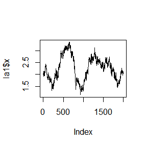

```r
la.Me<- function(sigma,x_0,N){
  x<- numeric(N)#链
  x[1]<- x_0
  u<- runif(N)
  k<- 0#拒绝
  for (i in 2:N) {
    y<- rnorm(1,x[i-1],sigma)
    if(u[i]<= (exp(-abs(y))/exp(-abs(x[i-1]))))
      x[i]<- y else{
        x[i]<- x[i-1]
        k<- k+1
      }
  }
  return(list(x=x,k=N-k))
}
la1<- la.Me(0.05,2,2000)
la2<- la.Me(0.5,2,2000)
la3<- la.Me(1,2,2000)
la4<- la.Me(2,2,2000)
plot(la1$x,type = "l",col=1)
```

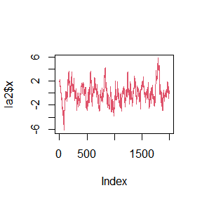

```r
plot(la2$x,type = "l",col=2)
```

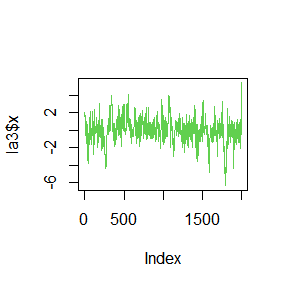

```r
plot(la3$x,type = "l",col=3)
```

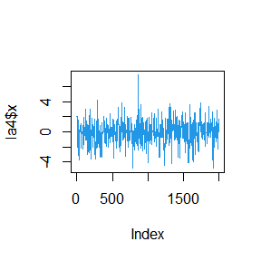

```r
plot(la4$x,type = "l",col=4)
```

```r
print(c(la1$k/2000,la2$k/2000,la3$k/2000,la4$k/2000))
```

```
## [1] 0.9820 0.8370 0.6845 0.5260
```

## Gelman-Rubin for 9.4

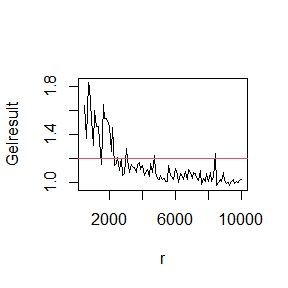

```r
#定义Gelman-Rubin函数
Gel<- function(psi){
  psi<- as.matrix(psi)
  n<-nrow(psi)
  k<-ncol(psi)
  psi.means<- rowMeans(psi)
  B<- n*var(psi.means)
  psi.w<- apply(psi, 1,var)
  W<- mean(psi.w)
  v.hat<- W*(n-1)/n + (B/n)
  r.hat<- v.hat/W
  return(r.hat)
}
las<- function(n,sigma,x_0,N){
  data<- matrix(0,nrow = n,ncol = N)
  for (i in 1:n) {
    data[i,]<- la.Me(sigma,x_0,N)$x
  }
  return(data)
}
r<- seq(500,10000,by= 100)
l<- length(r)
Gelresult<-numeric(l)
for (i in 1:l) {
  newla<- las(20,0.2,20,r[i])
  psi<- t(apply(newla,1,cumsum))
  for (j in 1:nrow(psi)) {
    psi[j,]<- psi[j,]/(1:ncol(psi))
  }
  Gelresult[i]<- Gel(psi)
}
plot(r,Gelresult,type = 'l')
abline(h=1.2,col=2)
```

## 11.4

```r
a<- c(4:25,100,500,1000)
result<- numeric(length(a))
for (i in 1:25) {
  k<-a[i]
  s<- function(a){pt(sqrt((k-1)*a^2/(k-a^2)),k-1)-pt(sqrt(k*a^2/(k+1-a^2)),k)}
  result[i]<- uniroot(s,interval = c(0.01,sqrt(k)-0.01))$root
}
data.frame(cbind(a,result))
```

```
##       a    result
## 1     4  1.492073
## 2     5  1.533555
## 3     6  1.562745
## 4     7  1.584429
## 5     8  1.601184
## 6     9  1.614516
## 7    10  1.625389
## 8    11  1.634418
## 9    12  1.642026
## 10   13  1.648552
## 11   14  1.654175
## 12   15  1.659099
## 13   16  1.663454
## 14   17  1.667287
## 15   18  1.670733
## 16   19  1.673832
## 17   20  1.676605
## 18   21  1.679148
## 19   22  1.681468
## 20   23  4.785832
## 21   24  4.888979
## 22   25  4.990000
## 23  100  9.990000
## 24  500 22.350680
## 25 1000 31.612777
```

# 11.24

# ME

```r
L <- c(0.01,0.1) #initial estimation
tol <- .Machine$double.eps^0.5
L.old<- L
N<-5 #max iter
like<- 1:N
pq<-matrix(0,N,2)
for (i in 1:N) {
  LL <- function(lam,y){
    lam3<- 1- lam[1]-lam[2]
    f1<- 2*444*log(lam[1]) + 2*132*log(lam[2])+ 2*361*log(lam3)+63*log(lam[1]*lam[2])
    L3<- 1-L[1]-L[2]
    f2<- (2*L3/(L[1]+2*L3))*444*log(lam3/lam[1]) + (2*L3/(L[2]+2*L3))*132*log(lam3/lam[2])
    f<- f1+f2
    return(-f)
  }
  opt<- optim(L,LL,y=y)
  L<- opt$par
  like[i]<- -opt$value
  pq[i,]<-L
  if(sum(abs(L-L.old))<tol)break
  L.old<-L
}
for (j in 1:i) {
  cat(j,'次')
  print('似然比：')
  print(like[j])
  print('p,q的估计')
  print(pq[j,])
}
```

```
## 1 次[1] "似然比："
## [1] -1726.374
## [1] "p,q的估计"
## [1] 0.2547434 0.1009825
## 2 次[1] "似然比："
## [1] -1789.984
## [1] "p,q的估计"
## [1] 0.2900680 0.1023675
## 3 次[1] "似然比："
## [1] -1800.038
## [1] "p,q的估计"
## [1] 0.2963112 0.1026060
## 4 次[1] "似然比："
## [1] -1801.831
## [1] "p,q的估计"
## [1] 0.2973837 0.1027181
## 5 次[1] "似然比："
## [1] -1802.159
## [1] "p,q的估计"
## [1] 0.2976292 0.1027139
```

```r
f<- function(lam){
  lam3<- 1-lam[1]-lam[2]
  f1<- 444*log(lam[1]^2+2*lam[1]*lam3)+132*log(lam[2]^2+2*lam[2]*lam3)
  f2<- 63*log(lam[1]*lam[2])+ 361*2*log(lam3)
  return(-(f1+f2))
}
#极大似然估计
optim(c(0.3,0.1),f)$par
```

```
## [1] 0.2976126 0.1027036
```

## p204 3

```r
f <- list(
  mpg ~ disp,
  mpg ~ I(1 / disp),
  mpg ~ disp + wt,
  mpg ~ I(1 / disp) + wt
)
for (i in 1:4) {
  p <- parse(text = f[i])[[1]]
  fit<- lm(p,data=mtcars)
  print(fit)
}
```

```
##
## Call:
## lm(formula = p, data = mtcars)
##
## Coefficients:
## (Intercept)         disp
##    29.59985     -0.04122
##
##
## Call:
## lm(formula = p, data = mtcars)
##
## Coefficients:
## (Intercept)    I(1/disp)
##       10.75      1557.67
##
##
## Call:
## lm(formula = p, data = mtcars)
##
## Coefficients:
## (Intercept)         disp           wt
##    34.96055     -0.01772     -3.35083
##
##
## Call:
## lm(formula = p, data = mtcars)
##
## Coefficients:
## (Intercept)    I(1/disp)           wt
##      19.024     1142.560       -1.798
```

```r
lapply(f,function(x){lm(x,data = mtcars)})
```

```
## [[1]]
##
## Call:
## lm(formula = x, data = mtcars)
##
## Coefficients:
## (Intercept)         disp
##    29.59985     -0.04122
##
##
## [[2]]
##
## Call:
## lm(formula = x, data = mtcars)
##
## Coefficients:
## (Intercept)    I(1/disp)
##       10.75      1557.67
##
##
## [[3]]
##
## Call:
## lm(formula = x, data = mtcars)
##
## Coefficients:
## (Intercept)         disp           wt
##    34.96055     -0.01772     -3.35083
##
##
## [[4]]
##
## Call:
## lm(formula = x, data = mtcars)
##
## Coefficients:
## (Intercept)    I(1/disp)           wt
##      19.024     1142.560       -1.798
```

## p213 3

```r
trials <- replicate(
  100,
  t.test(rpois(10, 10), rpois(7, 10)),
  simplify = FALSE
)
sapply(trials, function(x){return(x$p.value)})
```

```
##   [1] 0.33350859 0.72280736 0.10215113 0.62771301 0.63464643 0.41434572
##   [7] 0.89981894 0.64758106 0.84242462 0.11403886 0.08387984 0.07434339
##  [13] 0.15135347 0.55491586 0.06522973 0.88609804 0.09427698 0.67653800
##  [19] 0.04964828 0.51543061 0.37070147 0.34063682 0.53028335 0.71968639
##  [25] 0.28057986 0.90900574 0.09197786 0.28036481 0.15689347 0.80143062
##  [31] 0.98564938 0.78387783 0.86920107 0.36007035 0.44490270 0.42509524
##  [37] 0.02640738 0.65833924 0.21908421 0.21835206 0.19566389 0.23786357
##  [43] 0.75711229 0.34656631 0.68722194 0.06365324 0.97711803 0.55780991
##  [49] 0.02307376 0.64987600 0.71233506 0.47770470 0.62898443 0.77947848
##  [55] 0.81988420 0.99490481 0.79576498 0.06894024 0.44148606 0.26670847
##  [61] 0.64452859 0.17807032 0.43774678 0.63593616 0.23969278 0.47789230
##  [67] 0.33595624 0.52772151 0.72673724 0.59119873 0.92958565 0.34722105
##  [73] 0.44695044 0.43333636 0.18235531 0.22205632 0.14048186 0.22547811
##  [79] 0.08940749 0.41932612 0.96717954 0.10639226 0.28962584 0.56649831
##  [85] 0.19573949 0.80955299 0.47634046 0.70500275 0.83298176 0.90186788
##  [91] 0.58540099 0.52517119 0.87769152 0.97178038 0.29759697 0.15397670
##  [97] 0.05378379 0.67009978 0.92409954 0.92832944
```

## p214 6

```r
lapply1<-function(X,funct,t){
  Map(function(x){vapply(x, funct,t)},X)
}
#其中t为输出类型，X是输入列表的列表，funct是函数
trials <- replicate(
  6,
  t.test(rpois(10, 10), rpois(7, 10)),
  simplify = FALSE
)
trials1 <- replicate(
  5,
  t.test(rpois(10, 10), rpois(7, 10)),
  simplify = FALSE
)
X<- list(trials,trials1)
lapply1(X,function(x){return(x$p.value)},numeric(1))
```

```
## [[1]]
## [1] 0.4783229 0.4751261 0.5997565 0.3529811 0.5876717 0.2663979
##
## [[2]]
## [1] 0.7633297 0.9667008 0.5003538 0.6547896 0.7675956
```

```r
#函数输出效果
```

## 1

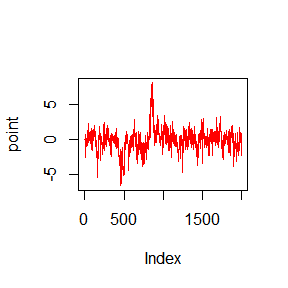

```r
library(StatComp20089)

sigma=1
x_0=0
N = 2000

la.Me<- function(sigma,x_0,N){
  x<- numeric(N)#链
  x[1]<- x_0
  u<- runif(N)
  k<- 0#拒绝
  for (i in 2:N) {
    y<- rnorm(1,x[i-1],sigma)
    if(u[i]<= (exp(-abs(y))/exp(-abs(x[i-1]))))
      x[i]<- y else{
        x[i]<- x[i-1]
        k<- k+1
      }
  }
  return(list(x=x,k=N-k))
}
x1=la.Me(1,0,2000)$x

x2=cla(sigma,x_0,N)

plot(x1,col="red",type="l",ylab="point")
```

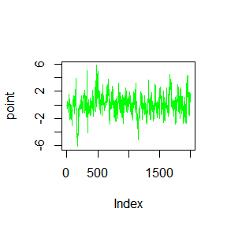

```r
plot(x2,col="green",type="l",ylab="point")
```

红色图是R，绿色是rcpp。

## 2

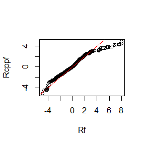

```r
Rf = x1[-(1:500)]
Rcppf = x2[-(1:500)]
qqplot(Rf,Rcppf)
abline(a=0,b=1,col='red')
```

发现基本在对角线上分布，所以可以认为同分布。

## 3

```r
library(microbenchmark)

(time = microbenchmark(Rf=la.Me(2,0,2000)$x,Rcppf=cla(sigma,x_0,N)))
```

```
## Unit: microseconds
##   expr    min      lq     mean  median      uq     max neval
##     Rf 4100.1 5543.45 7022.318 6571.85 7421.55 17937.8   100
##  Rcppf  362.4  447.20  498.856  498.60  520.00  1015.0   100
```

## 4

可以看出来rcpp和r得到的结果基本一致，但是rcpp的速度更加快。